# Nachholprüfung *Wissenschaftliches Schreiben*

Südwest Jiaotong Universität, Wintersemester 2022/23

Aufgaben

Prüfer:in

Dr. Daniel Jach

Prüfungsdatum

30. Dezember 2022

[output not shown]

## 1 Tagebucheintrag

**Schreiben Sie** einen Text über Ihre persönliche Schreiberfahrung im Stil eines Tagebucheintrags (ich-Form, informeller, mündlicher Stil).

- Was finden Sie beim Schreiben besonders schwierig?
- Was ist für Sie das Wichtigste beim Schreiben?
- Was zeichnet Ihrer Meinung nach einen guten Text aus?

**Reflektieren Sie** Ihre eigene Schreiberfahrung, indem Sie von Erlebnissen erzählen und Lehren ziehen oder Beispiele aus Ihrem Leben geben und überdenken. Ihr Text sollte zwischen 200 und 400 Wörter lang sein.

## 2 Arbeitsplan

**Erarbeiten Sie** einen Zeit- und Arbeitsplan für Ihre Bachelorarbeit. Beachten Sie dabei Folgendes.

- Haben Sie schon ein Thema und relevantes Vorwissen?
- Lesen und Schreiben in einer Fremdsprache braucht viel Zeit.
- Haben Sie noch andere Aufgaben in diesem Jahr? (Praktikum, Kurse, …)
- Was, wenn etwas schief geht?
- Vergessen Sie nicht, Pausen einzuplanen.

## 3 Expose

**Schreiben Sie** ein (informelles) Exposé Ihres wissenschaftlichen Bubble-Tee-Projekts. **Nutzen Sie** dabei das Modell der Waage für wissenschaftliches Argumentieren. **Formulieren Sie** erst Ihre Forschungsfrage. **Beschreiben Sie** dann das Waage-Modell von unten nach oben.

Beschreiben Sie das gewählte Material und begründen Sie Ihre Auswahl. Erläutern Sie Ihre Untersuchungsmethode. Formulieren Sie erste Erkenntnisse oder Vermutungen (Hypothesen) und nennen Sie potentielle Belege in Ihrem Material. Schreiben Sie ungefähr 150 Wörter.

> Meine Arbeit versucht, folgende Frage zu beantworten: …  
> Als Material nutze ich … / Grundlage meiner Untersuchung sind …  
> Ich werde das Material mit Blick auf … analysieren / durchsuchen / interpretieren / vergleichen / beschreiben / …  
> Ich erwarte, … / Ich vermute, …  
> X in meinem Material zeigt, dass … / Y sind Belege für …

**Erklärung aus dem Unterricht**

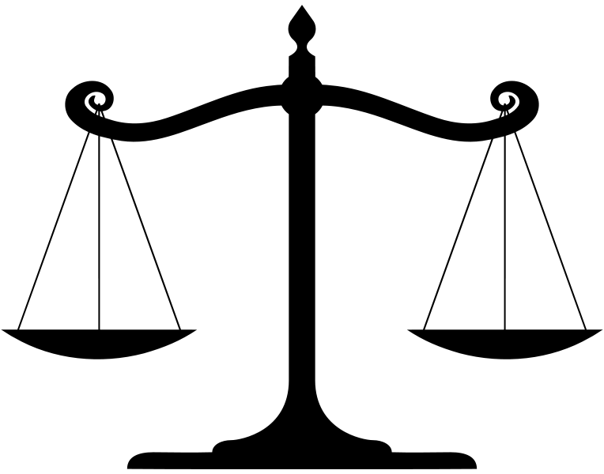

Der Sockel der Waage ist das Material. Der Balken ist die Methode. In den Waagschalen liegen Hypothesen einerseits, Belege andererseits. Die Untersuchungsmethode (= Antwort auf die Frage *Was mache ich mit meinem Material, um Belege für meine Hypothesen zu finden?*) verbindet Material, Hypothesen und Belege. Ihre Hypothesen und Belege müssen *ausbalanciert* sein: Für jede Behauptung (= Hypothese) brauchen Sie einen Beleg.

## 4 Abstract

**Formulieren Sie** ein Abstract. Die Endversion sollte zwischen 120 und 150 Wörtern lang sein. Die wochenlangen Übungen im Unterricht können Sie jetzt nicht mehr nachholen. Das folgende Beispiel aus dem Unterricht können Sie als Modell nutzen.

**Beispiel aus dem Unterricht**

Sollte das wissenschaftliche Schreiben als allgemeine Wissenschaftssprache vermittelt werden oder sollten die sprachlichen Anforderungen in den jeweiligen Disziplinen berücksichtigt werden? Die Antwort auf diese Frage hängt auch davon ab, wie stark sich die Wissenschaftssprachen unterscheiden. In der vorliegenden Studie wurden wissenschaftssprachliche Besonderheiten anhand zweier Korpora untersucht, die deutschsprachige Dissertationen der Fächer Betriebswirtschaftslehre (BWL) bzw. Maschinenbau (MB) umfassten und in denen der Gebrauch von Mehrworteinheiten (z.B. im vergleich zu den) verglichen wurde. Die Untersuchung verdeutlicht den unterschiedlichen Gebrauch der Mehrworteinheiten zwischen den Disziplinen: Nur vierzehn der 50 häufigsten Mehrworteinheiten wurden in beiden Korpora genutzt. Die Ergebnisse werden mit Blick auf die Vermittlung des wissenschaftlichen Schreibens erörtert. Es werden Überlegungen zur Weiterentwicklung der Methode angestellt und es wird diskutiert, wie die Korpuslinguistik die Schreibvermittlung im Studium unterstützen könnte.

(Krekeler, Christian. 2020. „Schreiben im Studium: Eine korpuslinguistische Untersuchung zum Sprachgebrauch in den Studiengängen Maschinenbau und Betriebswirtschaft“. *Zeitschrift für Interkulturellen Fremdsprachenunterricht* 25 (2): 207–35.)

## 5 Bibliographische Einträge

**Bibliografieren Sie** drei relevante Quellen in Ihrem Portfolio. Folgen Sie dabei wissenschaftlichen Standards.

## 6 Märchen

**Schreiben Sie** den Aufsatz von Flecken und Von Stutterheim als Märchen (200 Wörter) um. Speichern Sie Ihr Märchen als Kapitel in Ihrem Portfolio.

> Es waren einmal zwei Forschende, die …

Aufsatz von Flecken und Von Stutterheim

## 7 Wiedergabe

**Referieren Sie** den Forschungsbeitrag von Ballstaedt u.a. 1981. Zitieren Sie dabei eine zentrale Aussage wörtlich. Ihr Text sollte folgende Fragen beantworten: (1) Wer hat den Text verfasst? (2) Wo ist der Text erschienen? (3) Was will der Autor herausfinden? (4) Wie geht der Autor vor? (5) Zu welchen Ergebnissen kommt der Autor?

Forschungsbeitrag von Ballstaedt u.a.

## 8 Rezension

**Schreiben Sie** eine wissenschaftliche Buchrezension über eine selbst gewählte Arbeit aus Ihrem Fachgebiet bzw. dem Themengebiet Ihrer Bachelorarbeit. Sie können Ihre Wahl mit mir absprechen. Folgen Sie in Aufbau, Stil und Formatierung den Beispielen aus dem Unterricht. Ihr Text soll nicht länger als zwei Seiten sein (600 bis 800 Wörter).